# mb21014_EMATM0061_A_Report

Fengfan Hu

15/12/2021

## Section A

```r
library(tidyverse) # Load tidyverse package
```

### A.1

Load the “finance_data_EMATM0061” csv file into R data frame called “finance_data_original”

```r
folder_name <- "."
file_name <- "finance_data_EMATM0061"

# Load data from "finance_data_EMATM0061" csv file into data frame.
finance_data_original <- read.csv(paste0(folder_name, "/", file_name, ".csv"))
```

Show the number of rows and columns in the data frame.

```r
# Show the number of row and column of the data frame.
cat(
  "The data frame have",
  finance_data_original %>% nrow(),
  "rows and",
  finance_data_original %>% ncol(),
  "columns."
  )
```

```
## The data frame have 1051 rows and 30 columns.
```

### A.2

```r
finance_data <- finance_data_original %>%
  # Select columns needed from original data frame.
  select(state_year_code,
         Details.Education.Education.Total,
         Details.Health.Health.Total.Expenditure,
         Details.Transportation.Highways.Highways.Total.Expenditure,
         Totals.Revenue,
         Totals.Expenditure) %>%
  # Rename columns to corresponding new name
  rename(education_expenditure=Details.Education.Education.Total,
         health_expenditure=Details.Health.Health.Total.Expenditure,
         transport_expenditure=Details.Transportation.Highways.Highways.Total.Expenditure,
         totals_revenue=Totals.Revenue,
         totals_expenditure=Totals.Expenditure)
```

Display a subset of the “finance_data” data frame consisting of the first five rows and first three columns (“state_year_code”,“education_expenditure”,“health_expenditure”).

```r
finance_data %>% head(c(5, 3))
```

|  | state_year_code | education_expenditure | health_expenditure |
| --- | --- | --- | --- |
| 1 | ALABAMA__1992 | 3570524 | NA |
| 2 | ALABAMA__1993 | 3663465 | NA |
| 3 | ALABAMA__1994 | 3969277 | 487044 |
| 4 | ALABAMA__1995 | 4400912 | 491648 |
| 5 | ALABAMA__1996 | 4872259 | 514380 |

### A.3

Create a new column “totals_savings” which is equal to the difference between revenue and the expenditure.

```r
finance_data <- finance_data %>% mutate("totals_savings"=totals_revenue - totals_expenditure)
```

Display a subset of the “finance_data” consisting of the first three rows and the specified four columns (“state_year_code”,“totals_revenue”,“totals_expenditure”,“totals_savings”).

```r
finance_data %>% select(state_year_code, totals_revenue, totals_expenditure, totals_savings) %>% head(3)
```

|  | state_year_code | totals_revenue | totals_expenditure | totals_savings |
| --- | --- | --- | --- | --- |
| 1 | ALABAMA__1992 | 10536166 | 9650515 | 885651 |
| 2 | ALABAMA__1993 | 11389335 | 10242374 | 1146961 |
| 3 | ALABAMA__1994 | 11599362 | 10815221 | 784141 |

### A.4

Separate “state_year_code” column into “state” column and “year” column.

```r
finance_data <- finance_data %>% separate(state_year_code, into=c("state", "year"), sep="__", convert=TRUE)
```

Convert the “state” column to the title case.

```r
finance_data <- finance_data %>% mutate(state=str_to_title(state))
```

Display a subset of the “finance_data” consisting of the first three rows and the specified five columns (“state”, “year”,“totals_revenue”,“totals_expenditure”,“totals_savings”).

```r
finance_data %>% select("state", "year", "totals_revenue", "totals_expenditure", "totals_savings") %>% head(3)
```

|  | state | year | totals_revenue | totals_expenditure | totals_savings |
| --- | --- | --- | --- | --- | --- |
| 1 | Alabama | 1992 | 10536166 | 9650515 | 885651 |
| 2 | Alabama | 1993 | 11389335 | 10242374 | 1146961 |
| 3 | Alabama | 1994 | 11599362 | 10815221 | 784141 |

### A.5

Filter data frame with only four states “Louisiana”, “Montana”, “Mississippi” and “Kentucky” remains.

```r
finance_data_four_states <- finance_data %>% filter(state=="Louisiana" | state=="Montana" | state=="Mississippi" | state=="Kentucky")
```

Plot Year-Revenue graph by using geom_smooth function.

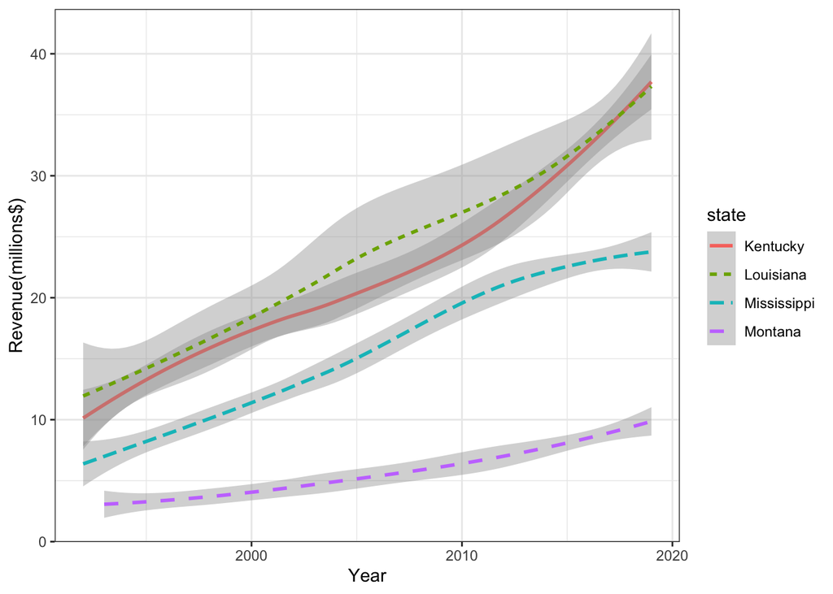

```r
# We convert "totals_revenue" to millions by dividing 1,000,000
ggplot(data = finance_data_four_states, aes(x=year, y=(totals_revenue/1000000)))+
  geom_smooth(aes(color=state, linetype=state), method='loess', formula="y~x")+
  labs(x="Year", y="Revenue(millions$)")+
  theme_bw()
```

### A.6

Create a function which takes as input a number and rounds it down to the nearest multiple of 10.

```r
get_decade <- function(num) {
  return (floor(num/10)*10)
}
```

Create a new column “decade” which give the decade corresponding to the year column by using get_decade() function.

```r
finance_data <- finance_data %>% mutate(decade=get_decade(year))
```

Show the first three states that had the highest mean-average savings (“totals_savings”) over the decade starting 2000.

```r
finance_data %>%
  # Get the data of which the decade equal to 2000
  filter(decade==2000) %>%
  # Group by "state"
  group_by(state) %>%
  # Get the mean average savings of each state.
  summarise(mean_avg_savings=mean(totals_savings, na.rm=TRUE)) %>%
  # Sort "mean_avg_savings" by descending order.
  arrange(desc(mean_avg_savings)) %>%
  # Display the first three states with the highest "mean_avg_savings".
  head(c(3,1))
```

| state |
| --- |
| Texas |
| Ohio |
| California |

### A.7

```r
alaska_summary <- finance_data %>%
  # Get the 1990, 2000 and 2010 decades data from Alaska.
  filter(state=="Alaska" & (decade==1990 | decade==2000 | decade == 2010)) %>%
  # Group by "decade"
  group_by(decade) %>%
  summarise(
    # Compute the mean and median of "education_expenditure", "health_expenditure" and "transport_expenditure" and name it by "{substr(.col, 0, 2)}_{.fn}" format.
    across(
      .cols = c(education_expenditure, health_expenditure, transport_expenditure),
      .fns = list(mn = ~mean(.x, na.rm=TRUE), md = ~median(.x, na.rm=TRUE)),
      .names = "{substr(.col, 0, 2)}_{.fn}"
    )
  )

# Display alaska_summary
alaska_summary
```

| decade | ed_mn | ed_md | he_mn | he_md | tr_mn | tr_md |
| --- | --- | --- | --- | --- | --- | --- |
| 1990 | 1246426 | 1246864 | 162785.3 | 164545.5 | 582136.8 | 582709.5 |
| 2000 | 1546233 | 1566815 | 152003.2 | 160168.0 | 723347.2 | 687407.0 |
| 2010 | 2642603 | 2595207 | 274688.0 | 278394.0 | 1210822.1 | 1271514.0 |

### A.8

Create a function which helps to impute the NA value by median.

```r
impute_by_median <- function(x) {
  md <- median(x, na.rm = TRUE)
  impute_f <- function(z) {
    if(is.na(z)) {
      return (md)
    } else {
      return (z)
    }
  }
  return (map_dbl(x, impute_f))
}
```

Generate a subset of “finance_data” which the state column takes the value “Idaho” and the “decade” column takes the value 2000 and includes all columns except from “state” and “decade”.

```r
idaho_2000 <- finance_data %>% filter(state=="Idaho" & decade==2000) %>% select(!c(state, decade))
```

Impute NA value from “education_expenditure” to “totals_savings” by median.

```r
idaho_2000_imputed <- idaho_2000 %>% mutate(across(education_expenditure:totals_savings, ~impute_by_median(.x)))
```

Display a subset of “idaho_2000_imputed” consisting the first five rows and the four columns (“year”, “health_expenditure”, “education_expenditure” and “totals_savings”).

```r
idaho_2000_imputed %>%
  # Select columns needed
  select(c("year", "health_expenditure", "education_expenditure", "totals_savings")) %>%
  # Show the first 5 rows.
  head(5)
```

|  | year | health_expenditure | education_expenditure | totals_savings |
| --- | --- | --- | --- | --- |
| 1 | 2000 | 98510.0 | 1663980 | 1083732 |
| 2 | 2001 | 103705.0 | 1768837 | 334438 |
| 3 | 2002 | 109896.5 | 1768837 | -746375 |
| 4 | 2003 | 116088.0 | 1886421 | 709085 |
| 5 | 2004 | 131165.0 | 1768837 | 1349740 |